# Anomaly Detection Exercise

2018-10-30 15:30:51

## Introduction

The task in this exercise is to identify or characterize anomalous prescription behavior in a synthetic dataset containing time series information of providers and three types of prescriptions. This document will describe how the data was processed and analyzed to identify anomalous behavior.

I will treat this analysis as an unsupervised learning problem, since the labels (over-prescriber status) is unknown. Unsupervised learning techniques are appropriate to find latent structure or identify groups in unlabeled data. In this exercise, I hope to identify over-prescribers by using k-means cluster analysis.

## Pre-Processing

As with any dataset, a number of pre-processing steps are necessary before beginning any analysis. This section will describe each pre-processing step.

First, any missing values were recoded as zeros. This might not be appropriate in all domains. Another possible technique would be to impute the missing values based on the mean or median of the feature. For the sake of this exercise, I assumed that a missing value in one of the patient or payment measures simply indicated no patients or payments for the month. Relatedly, there were a few negative values in the data, which did not make sense. I recoded negative values as zero.

Lastly, I identified instances where features were highly correlated (greater than 0.9) with another one another and dropped one of these duplicates. This process dropped one variable (cumulative Adderall payments) from the analysis.

## Exploratory Data Analysis

Next, I performed principal components analysis (PCA) to transform the features from highly-correlated ones into uncorrelated variables (‘principal components’). After running the analysis, and plotting the proportion of variance that is explained by each principal component, I see that the first two principal components explain just over a quarter of the variance in the data, and that the first ten principal components explain 75 percent of the variance.

Similarly, a biplot show some, but not great, separation among the features. These findings are somewhat expected since I have only a few variables to work with, and all of the features are derived from those in some way. Nevertheless, there is probably enough to work with to identify potential anomalous providers.

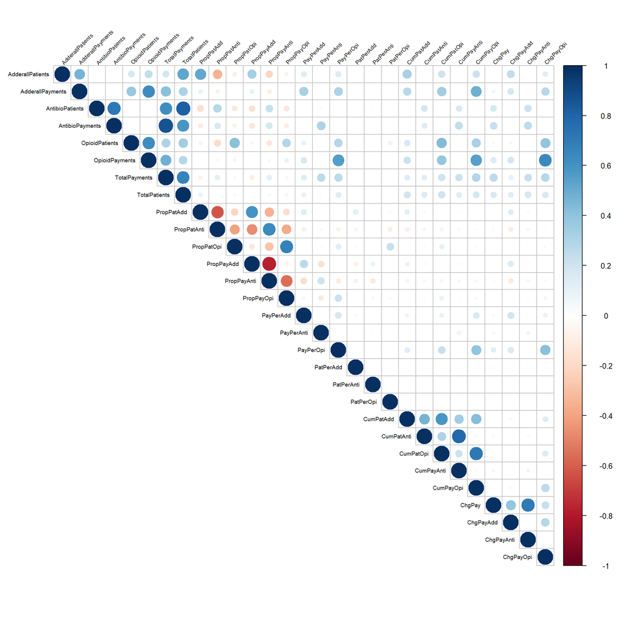

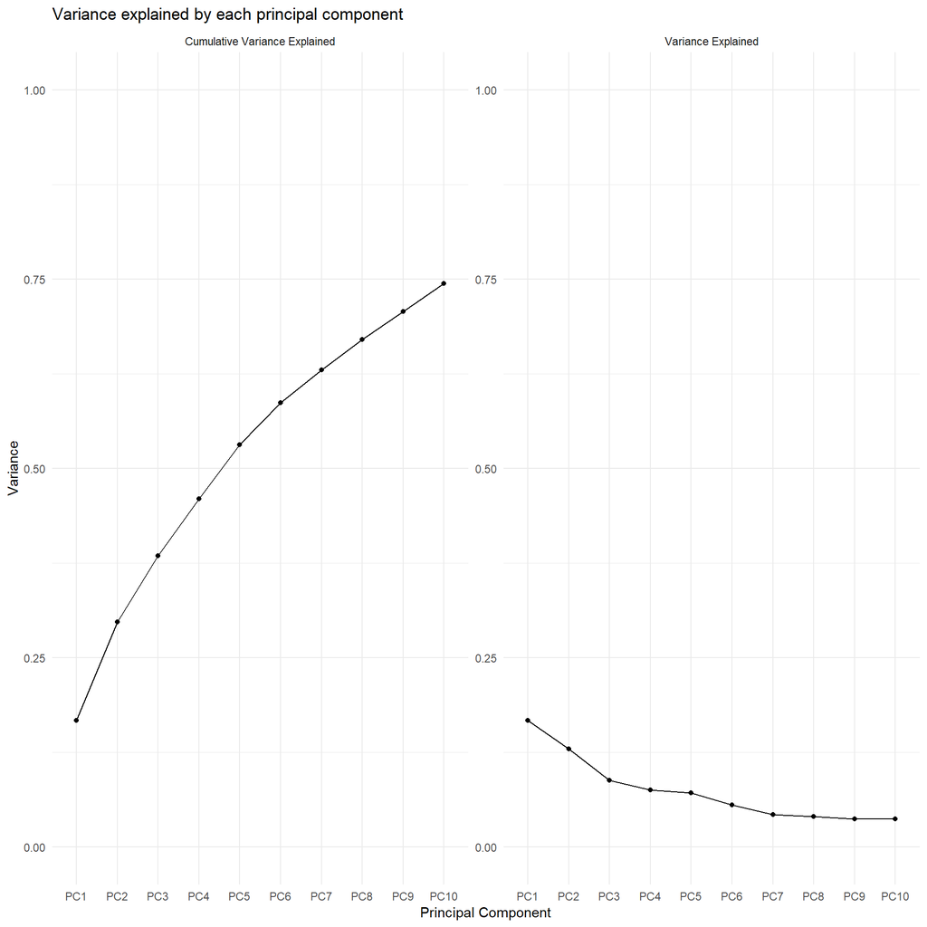

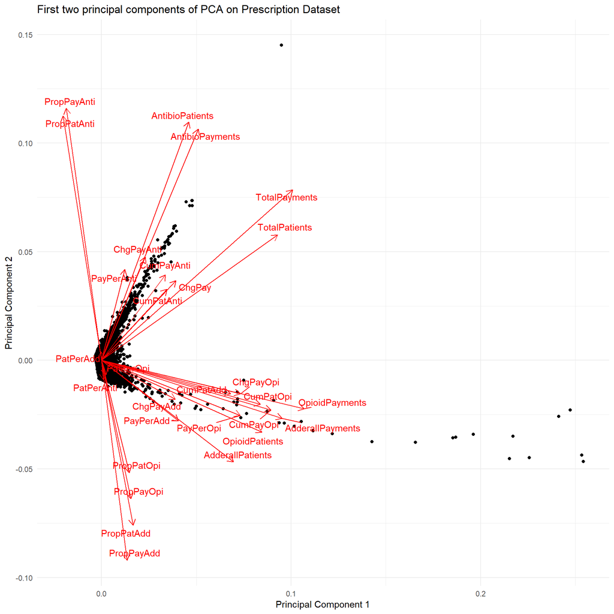

## K-means Clustering for Anomaly Detection

I decided to use an unsupervised technique, k-means clustering, to identify anomalous providers. K-means is an appropriate choice when working with unlabeled data, and is very easy to implement. K-means is preferable over another clustering method, such as hierarchical clustering, because I am not trying to uncover any latent hierarchy in the data.

The optimal number of clusters depends on the dataset, so one way to determine how many clusters should be used is to generate a range of clusters, and assess the error metric (sum of squared errors) to see where the metric begins to taper off or resemble an elbow. The plot below depicts the error metric against cluster values ranging from one to nine. There is an elbow shape around five or six clusters, suggesting this is an appropriate number of clusters to use on this dataset.

Using six clusters results in one particular cluster that looks interesting. It consists of 27 observations and five providers.

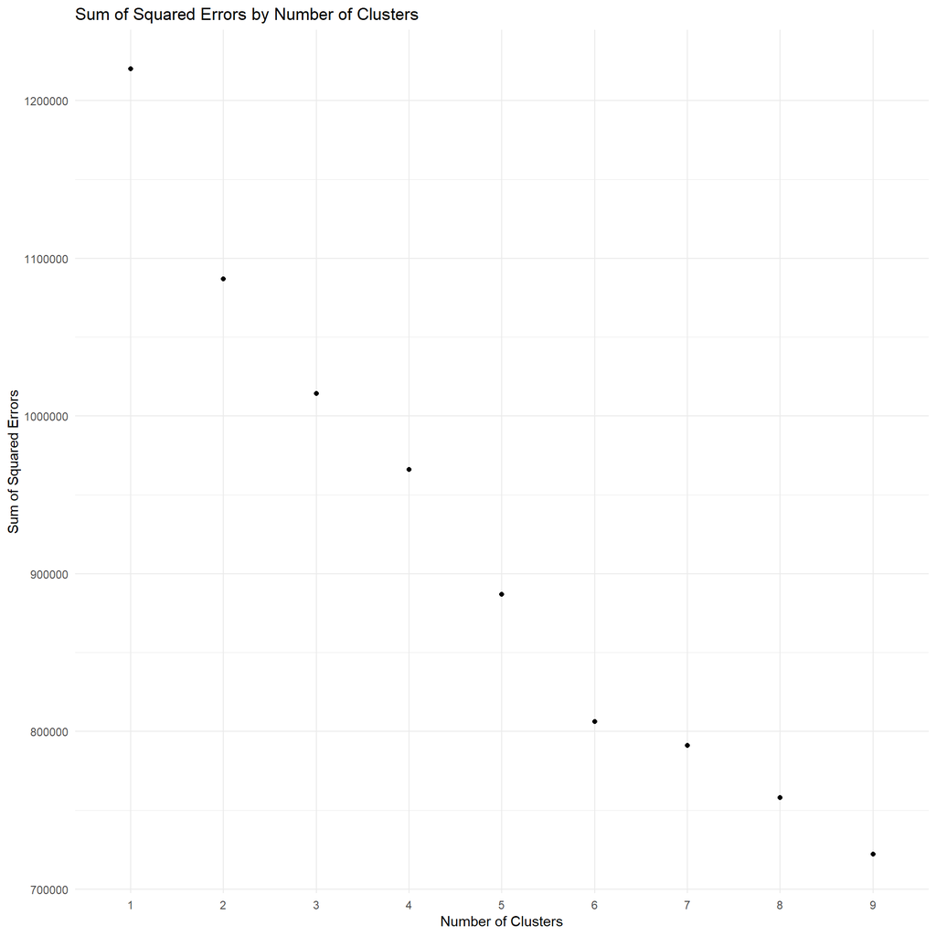

Cluster Observations and Provider Counts

| .cluster | Observations | Unique Providers |
| --- | --- | --- |
| 1 | 7322 | 2151 |
| 2 | 27 | 5 |
| 3 | 5140 | 1972 |
| 4 | 351 | 327 |
| 5 | 20610 | 2856 |
| 6 | 8624 | 1059 |

| Potentially Anomalous Provider IDs |
| --- |
| UY8bW4koFtgJI8J7 |
| GLwAKSb708GXX52I |
| wwyJwO6CL1dqIooh |
| azXdkxORxbkUXDV0 |
| YvXc9PhW83aoHti9 |

## Exploring outliers

Unscaled Feature Means by Cluster

| .cluster | AdderallPatients | AdderallPayments | AntibioPatients | AntibioPayments | OpioidPatients | OpioidPayments | TotalPayments | TotalPatients | PropPatAdd | PropPatAnti | PropPatOpi | PropPayAdd | PropPayAnti | PropPayOpi | PayPerAdd | PayPerAnti | PayPerOpi | PatPerAdd | PatPerAnti | PatPerOpi | CumPatAdd | CumPatAnti | CumPatOpi | CumPayAdd | CumPayAnti | CumPayOpi | ChgPay | ChgPayAdd | ChgPayAnti | … |
| --- | --- | --- | --- | --- | --- | --- | --- | --- | --- | --- | --- | --- | --- | --- | --- | --- | --- | --- | --- | --- | --- | --- | --- | --- | --- | --- | --- | --- | --- | --- |
| 1 | 8.9 | 3271.8 | 2.6 | 2526.5 | 0.5 | 116.7 | 5916.0 | 12.0 | 0.7 | 0.3 | 0.0 | 0.7 | 0.3 | 0.0 | 474.9 | 949.7 | 31.3 | 0.0 | 0.2 | 0.1 | 39.1 | 65.6 | 10.1 | 12122.0 | 201978.0 | 4538.3 | 68.6 | 1196.9 | 147.9 | … |
| 2 | 108.4 | 440998.0 | 4.0 | 40332.9 | 76.7 | 957265.8 | 1438597.7 | 189.2 | 0.5 | 0.2 | 0.3 | 0.4 | 0.1 | 0.5 | 4396.6 | 4446.4 | 12469.3 | 0.0 | 0.2 | 0.0 | 711.4 | 130.5 | 514.9 | 3477063.5 | 533166.9 | 5433702.7 | 21870.5 | 15696.0 | 307.6 | … |
| 3 | 0.8 | 129.9 | 1.4 | 1248.1 | 3.4 | 1672.0 | 3051.0 | 5.6 | 0.1 | 0.2 | 0.5 | 0.1 | 0.3 | 0.5 | 45.1 | 568.8 | 310.9 | 0.0 | 0.1 | 0.1 | 28.8 | 62.8 | 13.5 | 7837.0 | 192857.0 | 6920.9 | 29.9 | 39.1 | 73.0 | … |
| 4 | 3.0 | 2442.7 | 96.4 | 658562.1 | 1.1 | 477.5 | 661483.3 | 100.6 | 0.0 | 0.9 | 0.0 | 0.0 | 1.0 | 0.0 | 290.8 | 14780.1 | 54.4 | 0.1 | 0.0 | 0.0 | 35.1 | 165.5 | 11.2 | 11089.8 | 866051.7 | 3335.6 | 12647.9 | 403.8 | 57241.6 | … |
| 5 | 1.4 | 190.9 | 6.2 | 18572.1 | 0.5 | 61.9 | 18825.8 | 8.1 | 0.2 | 0.8 | 0.1 | 0.0 | 0.9 | 0.0 | 74.2 | 3433.6 | 29.7 | 0.1 | 0.0 | 0.0 | 19.7 | 42.0 | 6.7 | 4814.0 | 115973.1 | 1550.2 | 228.4 | 75.9 | 1166.8 | … |
| 6 | 1.8 | 280.5 | 7.6 | 25869.5 | 0.6 | 95.0 | 26246.0 | 10.1 | 0.2 | 0.7 | 0.1 | 0.1 | 0.9 | 0.0 | 88.4 | 3972.6 | 41.9 | 0.1 | 0.0 | 0.1 | 65.3 | 164.0 | 20.3 | 17543.1 | 625765.9 | 5480.0 | 296.3 | 133.2 | 1485.5 | … |

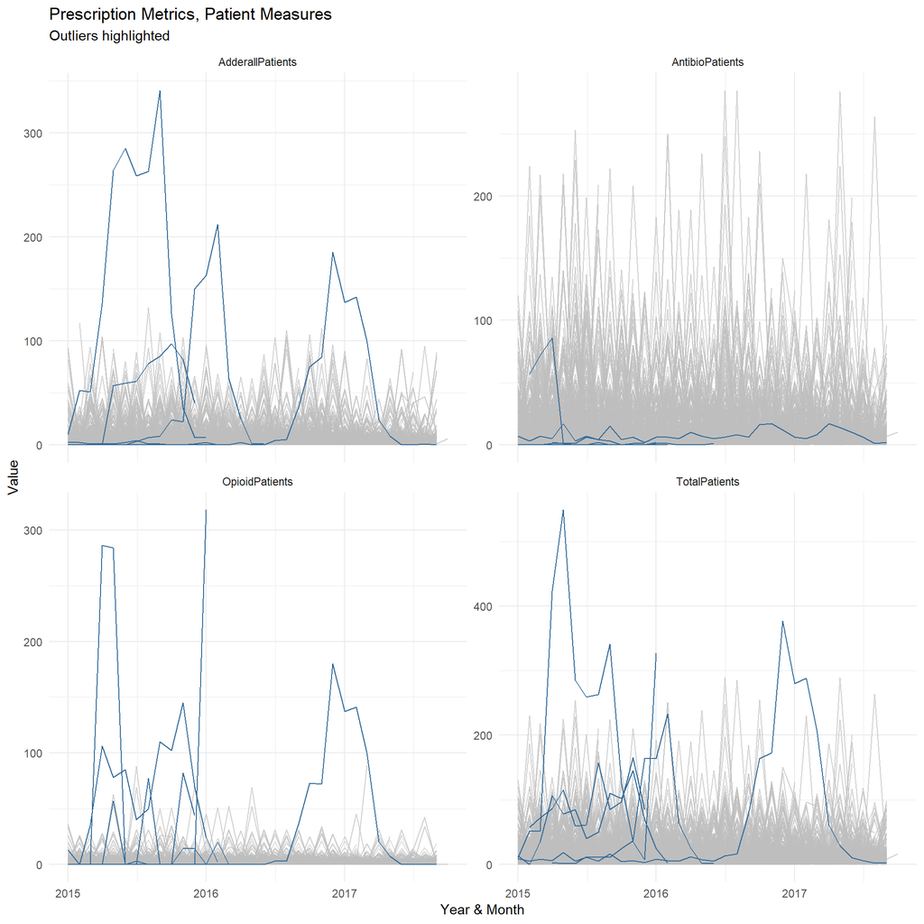

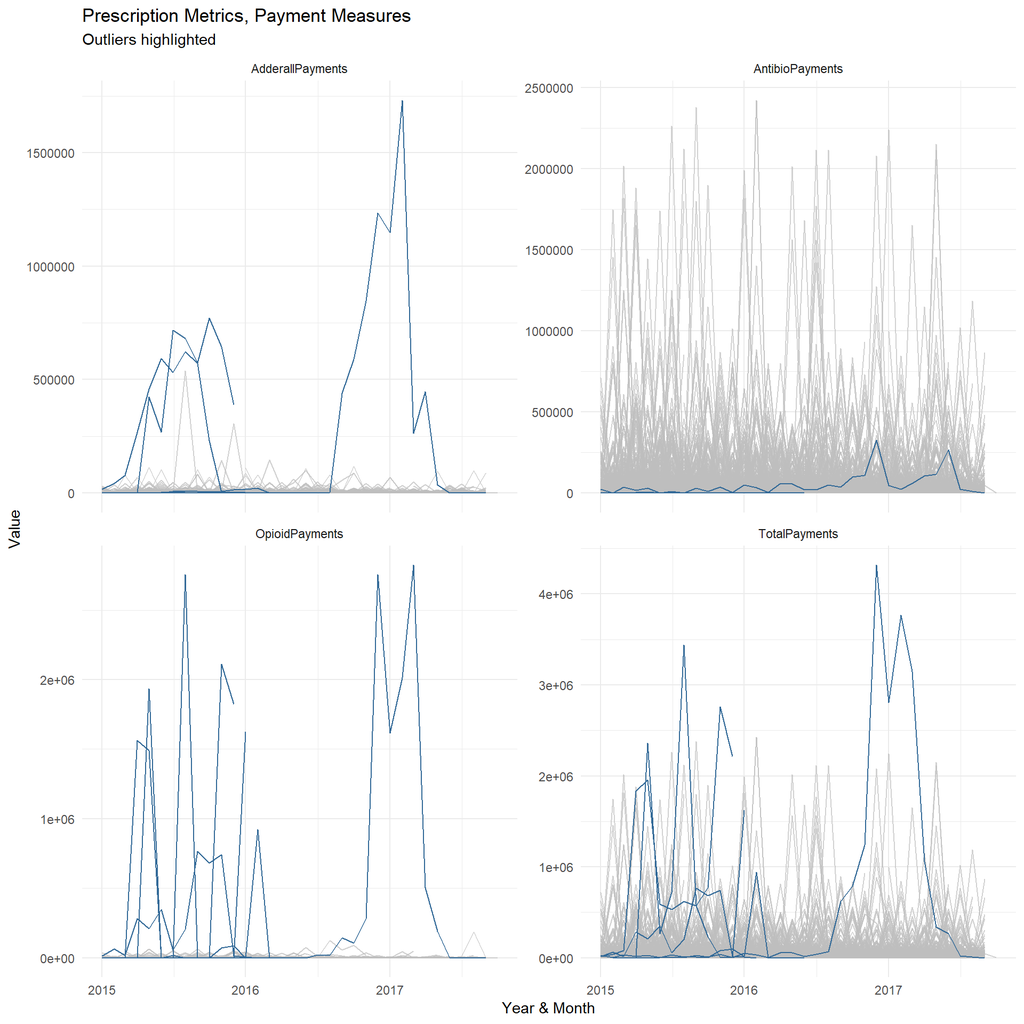

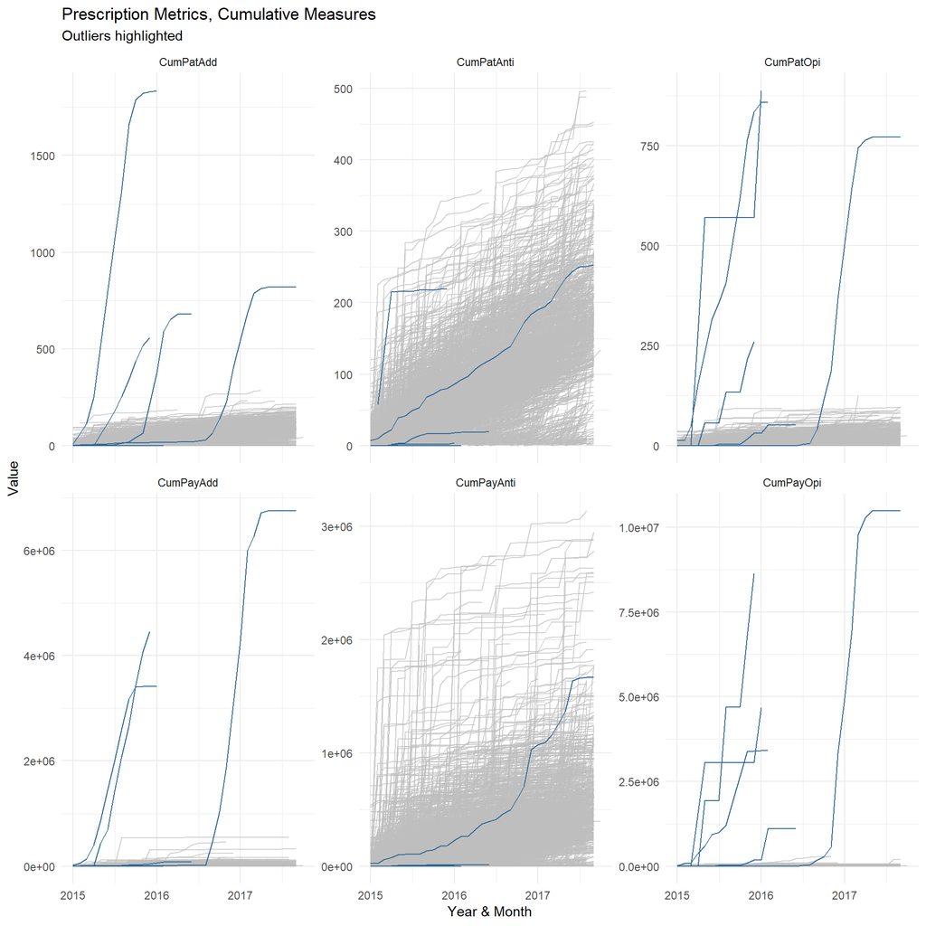

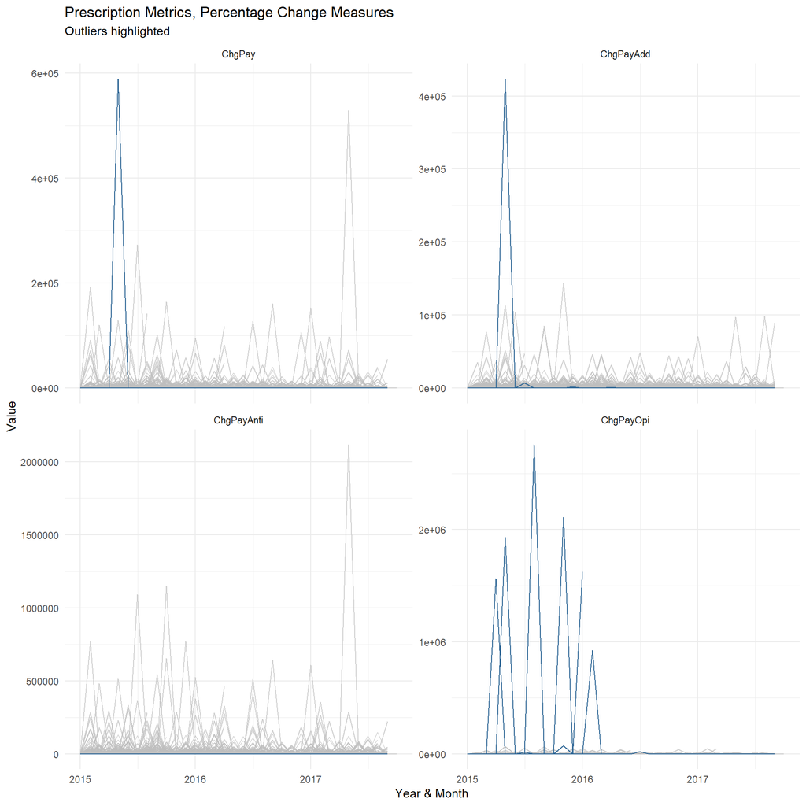

## Limitations and Further Research

First, I have only limited data and no context for the analysis. The providers I identified could be located in densely-populated areas, or specialize in ADHD & pain management, which might explain the high rates of Adderall and opioid prescriptions. If I had access to data regarding the locality, specialization, or other metrics regarding patients and payments, the analysis could be improved.

Second, although the data is time-series in nature, I did not attempt to decompose the time-series to its core components to identify seasonality, trend, or cyclical patterns. It is possible that using that technique may give different results.

Third, because I chose an unsupervised approach, I have no ability to confirm the accuracy of my findings. If the exercise included labels about known over-prescribing providers, I could build a supervised learning model that predicts the likelihood of over-prescribing.

Finally, I have no information about the resources available to investigate potentially anomalous providers. My approach identified five providers out of over 3,000, about one tenth of a percent. If an oversight agency has resources to investigate one percent, or just one provider, the results of my analysis may change.

## Conclusion

This was an enlightening exercise with real-world implications. As the prompt described, over-prescription creates serious challenges for public health. Using unsupervised learning techniques, I was able to identify five providers out of over 3,000 whose prescribing behavior seems anomalous and warrants further investigation.

The five providers with potentially anomalous prescribing patterns are those listed below.

| Potentially Anomalous Provider IDs |
| --- |
| UY8bW4koFtgJI8J7 |
| GLwAKSb708GXX52I |
| wwyJwO6CL1dqIooh |
| azXdkxORxbkUXDV0 |
| YvXc9PhW83aoHti9 |